# MATH-509: Lab 04

**Daniel Carter**

## Getting Started

Follow the instructions below to copy this notebook and to perform some initial setup.

1. Copy this notebook by selecting `File > Save a copy in Drive`.
2. A new window should open for the copied notebook. Move the new notebook to your course folder in Google Drive by selecting `File > Move` and then selecting the desired folder.
3. Update the name of the notebook by removing "Copy of" and replacing "Username" with your actual username.
4. Update the first cell in the notebook by replacing "Student Name" with your actual name.
5. Mount your Google Drive by running the cell below and accepting the prompts you are presented with.

```python
from google.colab import drive
drive.mount('/content/drive')
```

## Import Statements

Run the cell below to import the NumPy, SymPy, and Matplotlib packages. **No other import packages are to be used in this assignment.**

```python
import numpy as np
import sympy as sym
import matplotlib.pyplot as plt
```

# Problem 1 - Finding Roots

### Problem Background

In this problem, we will use SymPy to find the roots of a polynomial function.

### Instructions

**Part A.** In the cell below, create a SymPy variable named `x`. Then create an expression named `f` to represent the polynomial function shown below.

$$\large f(x) = 0.05 x^4 - 0.75 x^3 + 1.1 x^2 + 8 x + 35$$

After defining `f`, use the `display()` function to display it.

```python
x = sym.Symbol('x')
 f = lambda x: .05*x**4-.75*x**3+1.1*x**2+8*x+35
 f = f(x)
 display(f)
```

$\displaystyle 0.05 x^{4} - 0.75 x^{3} + 1.1 x^{2} + 8 x + 35$

**Additional Instructions**

**Part B.** Use the `nroots()` function from SymPy to find the roots of the function $f(x)$. Store the results in a variable named `roots`. Then print the value of this variable.

You should see four roots. The first two will be real numbers, but the second two will be complex numbers that contain imaginary terms.

```python
roots = sym.nroots(f)
print(roots)
```

```
[7.42524160580806, 11.3311490811291, -1.87819534346858 - 2.1891080260976*I, -1.87819534346858 + 2.1891080260976*I]
```

**Additional Instructions**

**Part C.** Run the cell below as-is. If you have named your variables as instructed and if your `roots` variable is correct, then you should see a plot of the function $f(x)$ with the two real roots indicated using orange dots.

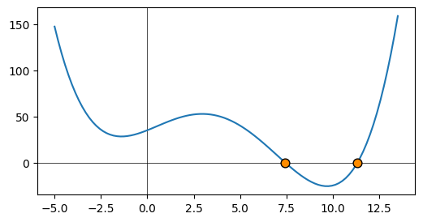

```python
x_vals = np.linspace(-5,13.5,100)
y_vals = [f.subs({x:x_}) for x_ in x_vals]
plt.figure(figsize=[6,3])
plt.axhline(0, c='k', linewidth=0.5)
plt.axvline(0, c='k', linewidth=0.5)
plt.plot(x_vals, y_vals)
plt.scatter(roots[:2], [0,0], c='darkorange', s=60, edgecolor='k', zorder=2)
#plt.yscale('symlog')
plt.show()
```

# Problem 2 - Solving an Equation

### Problem Background

In this problem, we will use SymPy to solve a poynomial equation.

### Instructions

**Part A**. We will again be working with the function $f(x)$ from Problem 1. Use the `nroots()` function from SymPy to find the solutions to the following equation:

$$f(x) = 50$$

This is accomplished by finding the roots of the expression $f(x) - 50$.

Store the results in a variable named `solns` and then print this variable.

Note that you do **not** need to create a new expression for the function $f(x)$. You can reuse the variable `f` created in Part 1.

```python
solns = sym.nroots(f-50)
solns
```

```
[-3.18302164784118, 1.96067612112378, 3.90154836542689, 12.3207971612905]
```

**Additional Instructions**

**Part B.** Run the cell below as-is. You should see a plot of the function $f(x)$ with the solutions to $f(x) = 50$ indicated by orange dots.

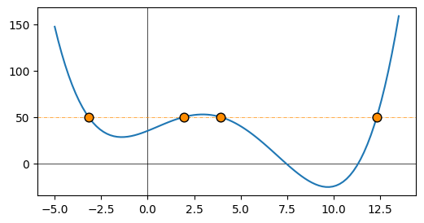

```python
x_vals = np.linspace(-5,13.5,100)
y_vals = [f.subs({x:x_}) for x_ in x_vals]
plt.figure(figsize=[6,3])
plt.axhline(0, c='k', linewidth=0.5)
plt.axvline(0, c='k', linewidth=0.5)
plt.axhline(50, c='darkorange', linestyle='-.', linewidth=0.5)
plt.plot(x_vals, y_vals)
plt.scatter(solns, [50, 50, 50, 50], c='darkorange', s=60, edgecolor='k', zorder=2)
#plt.yscale('symlog')
plt.show()
```

# Problem 3 - Derivatives

### Problem Background

In Problem 3, you will use SymPy to calculate the first and second derivatives of the function $f(x)$. We will use these derivatives in Problems 4 and 5.

### Instructions

Use SymPy to calculate the first and second derivatives of $f(x)$. Store these derivatives in variables and display them both using `display()`.

```python
df1 = f.diff()
df2 = df1.diff()
display(df1, df2)
```

$\displaystyle 0.2 x^{3} - 2.25 x^{2} + 2.2 x + 8$

$\displaystyle 0.6 x^{2} - 4.5 x + 2.2$

# Problem 4 - Linear Approximation

### Problem Background

One common application of derivatives is **linear approximation**. The derivative can be used to calculate the slope of the **tangent line** for the graph of a function at a particular point. Near the point of tangency, the tangent line can serve as an approximation of the orginal function.

Suppose that $y_T = f(x_T)$ and $m = f'(x_T)$. Then the equation of the line tangent to the curve $y = f(x)$ at the point $(x_T, y_T)$ is given by the equation below.

$$\large y = y_T + m (x - x_T)$$

In this problem, you will calculate the values $m$ and $y_T$ for a specific value of $x_T$.

### Instructions

**Part A.** Perform the following steps in the cell below:

1. Create a variable named `xT`, setting it equal to 2.1.
2. Calculate `yT` by using the `subs()` method to substitute `xT` into the expression for $f(X)$ from Problem 1.
3. Calculate `m` by using the `subs()` method to substitute `xT` into the expression for $f'(X)$ that was found in Problem 3.
4. Print `yT` and `m` using two different print statements.

```python
xT = 2.1
yT = f.subs({x:xT})
m = df1.subs({x:xT})
print(yT)
print(m)
```

```
50.6776550000000
4.54970000000000
```

**Additional Instructions**

**Part B.** Run the cell below as-is. You should see a plot of the function $f(x)$ along with the line tangent to the curve at the point $(x_T, y_T)$.

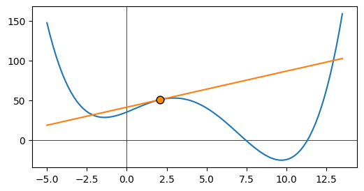

```python
x_vals = np.linspace(-5,13.5,100)
y_vals = [f.subs({x:x_}) for x_ in x_vals]
plt.figure(figsize=[6,3])
plt.axhline(0, c='k', linewidth=0.5)
plt.axvline(0, c='k', linewidth=0.5)
plt.plot(x_vals, y_vals)
plt.plot(x_vals, yT + m*(x_vals - xT))
plt.scatter([xT], [yT], c='darkorange', s=60, edgecolor='k', zorder=2)
plt.show()
```

# Problem 5 - Local Extrema

### Problem Background

In this problem, we will use the first and second derivatives of $f(x)$ to find and classify the critical points of the function.

### Instructions

**Part A.** Use the `nroots()` function from SymPy to find the critical points of the function `f(x)` from Problem 1. Store the roots in a variable named `crit_pts`, and then print this variable.

```python
crit_pts = sym.nroots(df1)
print(crit_pts)
```

```
[-1.39598493176487, 2.95748666265809, 9.68849826910677]
```

**Additional Instructions**

**Part B.** Calculate the values of the function $f(x)$ and the second derivative $f''(x)$ at each of the critical points. Store the values of the function in a list named `f_values` and store the values of the second derivative in a list named `df2_values`.

After constructing the lists, print both lists using two different print statements.

```python
f_values = []
df2_values = []
for cp in crit_pts:
  f_values.append(f.subs({x:cp}))
  df2_values.append(df2.subs({x:cp}))

print(f_values)
print(df2_values)
```

```
[28.2060021409971, 52.7053082409920, -25.7603338194891]
[9.65119655077063, -5.86065356608111, 14.9219570153105]
```

**Additional Instructions**

**Part C.** Run the cell below as-is. If your lists have been constructed correctly and named as instructed, you should see output classify each critical point as either a local minimum or a local maximum. You should also see a plot of $f(x)$ with the local extrema indicated by orange dots.

```
-1.3960 is a local minimum. The value of the function here is 28.2060.
2.9575 is a local maximum. The value of the function here is 52.7053.
9.6885 is a local minimum. The value of the function here is -25.7603.
```

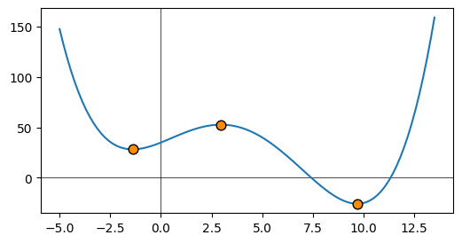

```python
for cp, fx, df2x in zip(crit_pts, f_values, df2_values):
    if df2x < 0:
        print(f'{cp:.4f} is a local maximum. The value of the function here is {fx:.4f}.')
    if df2x > 0:
        print(f'{cp:.4f} is a local minimum. The value of the function here is {fx:.4f}.')

x_vals = np.linspace(-5,13.5,100)
y_vals = [f.subs({x:x_}) for x_ in x_vals]
plt.figure(figsize=[6,3])
plt.axhline(0, c='k', linewidth=0.5)
plt.axvline(0, c='k', linewidth=0.5)
plt.plot(x_vals, y_vals)
plt.scatter(crit_pts, f_values, c='darkorange', s=60, edgecolor='k', zorder=2)
plt.show()
```

# Problem 6 - Calculating the Mean

### Problem Background

Let $x_1, x_2, ..., x_N$ be a sample of numerical observations. The mean of such a sample can be calculated as follows:

$$\large \bar x = \frac{1}{N}\sum_{i=1}^N x_i$$

The mean of a sample has some interesting geometric properties. In particular, it is the unique value that minimize the total squared deviation with respect to the points in the sample. To state this explicitly, define the **sum of squared deviations** function, $SSD(x)$, as follows:

$$\large SSD(x) = \sum_{i=1}^N \left(x_i - x \right)^2$$

Then the mean $\bar x$ is the value of $x$ for which $SSD(x)$ is minimized. We will explore this aspect of the mean in this problem.

### Instructions

**Part A.** A sample of 10 values is provided in the cell below. Add code to that cell to perform the following steps:

1. Define a SymPy symbol named `x`.
2. Create an expresion named `SSD` to represent the function $SSD(x)$. This can be accomplished as follows:

   a. Initialize `SSD` to 0.

   b. Use a loop to calculate each term in the sum that defines $SSD(x)$. Add each term to the variable `SSD`.
3. Use `display()` to display the expression representing $SSD(x)$.

```python
sample = [24, 75, 74, 37, 59, 78, 73, 78, 86, 62]

x = sym.Symbol('x')
ssd = 0

for i in sample:
  term = (i - x)**2
  ssd += term
display(ssd)
```

$\displaystyle \left(24 - x\right)^{2} + \left(37 - x\right)^{2} + \left(59 - x\right)^{2} + \left(62 - x\right)^{2} + \left(73 - x\right)^{2} + \left(74 - x\right)^{2} + \left(75 - x\right)^{2} + 2 \left(78 - x\right)^{2} + \left(86 - x\right)^{2}$

**Additional Instructions**

**Part B.** Perform the following steps in the cell below.

1. Calculate the derivative of $SSD(x)$.
2. Use `nroots()` to find the roots of $SSD(x)$. There should be only one.
3. Print the root found in the previous step.

```python
ssd_df = ssd.diff()
roots = sym.nroots(ssd_df)
print(roots)
```

```
[64.6000000000000]
```

**Additional Instructions**

**Part C.** We will now verfiy our calculation. Use `np.mean()` to calculate the mean of the sample, printing the result.

```python
mean = np.mean(sample)
print(mean)
```

```
64.6
```

# Problem 7 - Linear Regression Loss

### Problem Background

In this problem, we will explore how calculus techniques can be used to find the optimal paramater values for a machine learning model. We will focus our attention on a simplified version of the linear regression model known as the **no-intercept linear regression** model. Assuming that our model has only one feature $x$, the no-intercept model can be written as follows:

$$\large \hat y = m\cdot x$$

The variable $m$ is parameter that defines the model. The goal during training is to find the value of $m$ that minimizes the **sum of squared errors** metric for some training set of $(x_i, y_i)$ feature/label pairs. The definition of $SSE(m)$ is provided below.

$$\large SSE(m) = \sum_{i=1}^N \left(y_i - \hat y_i \right)^2 = \sum_{i=1}^N \left(y_i - m\cdot x_i \right)^2 $$

### Instructions

**Part A.** Two lists named `x_train` and `y_train` are provided below. These lists contain the feature and label values for a training set that we will use to train a no-intercept linear regression model.

Add code to the cell to perform the following steps:

1. Define a SymPy symbol named `m`.
2. Create an expression named `SSE` to represent the function $SSE(n)$. This can be accomplished as follows:

   a. Initialize `SSE` to 0.

   b. Use a loop to calculate each term in the sum that defines $SSE(m)$. Add each term to the variable `SSE`.
3. Use `display()` to display the expression representing $SSE(x)$.

```python
x_train = [60, 55, 66, 58, 65, 17, 72, 88, 42, 69, 51, 93, 95, 80, 29, 66, 74, 12, 89, 54]
y_train = [105, 79, 83, 68, 100, 58, 109, 133, 66, 118, 104, 149, 144, 132, 33, 80, 106, 9, 135, 72]

m = sym.Symbol('m')
sse = 0
for i in range(0,len(x_train)):
  term = (y_train[i] - m*x_train[i])**2
  sse += term
display(sse)
```

$\displaystyle \left(9 - 12 m\right)^{2} + \left(33 - 29 m\right)^{2} + \left(58 - 17 m\right)^{2} + \left(66 - 42 m\right)^{2} + \left(68 - 58 m\right)^{2} + \left(72 - 54 m\right)^{2} + \left(79 - 55 m\right)^{2} + \left(80 - 66 m\right)^{2} + \left(83 - 66 m\right)^{2} + \left(100 - 65 m\right)^{2} + \left(104 - 51 m\right)^{2} + \left(105 - 60 m\right)^{2} + \left(106 - 74 m\right)^{2} + \left(109 - 72 m\right)^{2} + \left(118 - 69 m\right)^{2} + \left(132 - 80 m\right)^{2} + \left(133 - 88 m\right)^{2} + \left(135 - 89 m\right)^{2} + \left(144 - 95 m\right)^{2} + \left(149 - 93 m\right)^{2}$

**Additional Instructions**

**Part B.** We will calculate the optimal slope $m$ for the model in Problem 8. First, we will calculate the value of $SSE(x)$ for some (arbitrary) slope $m =2$. Use the `subs()` method to plug 2 into $SSE(x)$ and print the result.

```python
result = sse.subs({m:2})
print(result)
```

```
23901
```

**Additional Instructions**

**Part C.** Run the cell below as-is. This will display a scatter plot of the training set along with a line representing the (non-optimal) model $\hat y = 2x$ that we scored in the cell above.

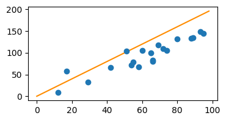

```python
x_vals = np.arange(0,100,2)
y_vals = 2 * x_vals
plt.figure(figsize=[4,2])
plt.scatter(x_train, y_train, zorder=2)
plt.plot(x_vals, y_vals, color='darkorange', zorder=1)
plt.show()
```

# Problem 8 - Minimizing Loss

### Problem Background

In this problem, we will find the value of the parameter $m$ that minimized the $SSE(m)$ loss from Problem 7.

### Instructions

**Part A.** In the cell below, calculate the derivative of $SSE(m)$. Use `display()` to display the derivative

Then use `nroots()` to find the critical points by calculating the roots of the derivative. Print the list of critical points. You should see only a single critical point.

```python
sse_df = sse.diff()
crit_pts = sym.nroots(sse_df)
print(crit_pts)
```

```
[1.51789568449118]
```

**Additional Instructions**

**Part B.** We will now calculate the minimum value for $SSE(m)$. The critical point found above is contained in a list. Use indexing to access that value and store it in a variable named `m0`. Then use `subs()` to plug the critical point into the expression for $SSE(m)$. Print the result.

```python
m0 = crit_pts[0]
result = sse.subs({m:m0})
print(result)
```

```
3763.50274119643
```

**Additional Instructions**

**Part C.** Run the cell below as-is. This will display a scatter plot of the training set along with a line representing the optimal model $\hat y = m\cdot x$.

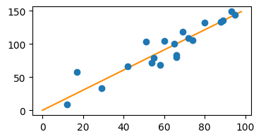

```python
x_vals = np.arange(0,100,2)
y_vals = m0 * x_vals
plt.figure(figsize=[4,2])
plt.scatter(x_train, y_train, zorder=2)
plt.plot(x_vals, y_vals, color='darkorange', zorder=1)
plt.show()
```

# Submission Instructions

1. The cell below will generate an HTML render of your notebook within the same Google Drive folder in which you stored this notebook. Adjust the path for your notebook in the cell below as needed.
2. Restart your notebook and run it from start to finish.
3. If the notebook executes without error, download the HTML export of the notebook and then upload it to Canvas. Make sure to carefully review the contents of the HTML export to ensure that everything is displayed correctly.
4. Click on "Share" in the upper-right corner of this notebook. Then select "Anyone with the link" from dropdown. Click "Copy Link" and paste the copied link as a comment in your submission on Canvas.

```python
%%capture
import time
time.sleep(30)
!jupyter nbconvert --to html /content/drive/MyDrive/MATH_509/Lab_04_dcarter8.ipynb
```